# Environments

# 1 Environments

The environment is the data structure that powers many important R features like lexical scoping, namespaces, and R6 classes, and interact with evaluation to give you powerful tools for making domain specific languages, like dplyr and ggplot2.

## 1.1 Basics

Create a new environment using `new.env()`:

```r
e1 <- new.env()  # base
e1$a <- FALSE
e1$b <- "a"
e1$c <- 2.3
e1$d <- 1:3

# rlang
e1 <- env(a = FALSE, b = "a", c = 2.3, d = 1:3)

names(e1)
```

```
## [1] "a" "b" "c" "d"
```

```r
env_names(e1)  # rlang function
```

```
## [1] "a" "b" "c" "d"
```

```r
print(e1)
```

```
## <environment: 0x000000001916fc58>
```

```r
env_print(e1)  # rlang function
```

```
## <environment: 000000001916FC58>
##   parent: <environment: global>
##   bindings:
##    * a: <lgl>
##    * b: <chr>
##    * c: <dbl>
##    * d: <int>
```

```r
typeof(e1)
```

```
## [1] "environment"
```

```r
class(e1)
```

```
## [1] "environment"
```

```r
attributes(e1)
```

The job of an environment is to associate, or bind, a set of names to a set of values.

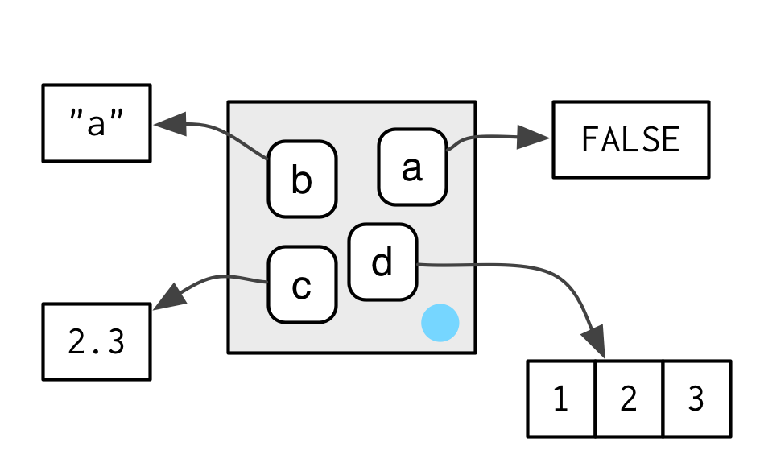

The objects don’t live in the environment so multiple names can point to the same object:

```r
e1$b <- e1$d
```

[figure not shown]

Environments have reference semantics: unlike most R objects, when you modify them, you modify them in place, and don’t create a copy. One important implication is that environments can contain themselves.

```r
e1$d <- e1
env_print(e1)
```

```
## <environment: 000000001916FC58>
##   parent: <environment: global>
##   bindings:
##    * a: <lgl>
##    * b: <int>
##    * c: <dbl>
##    * d: <env>
```

[figure not shown]

There is essentially infinite nesting:

```r
env_print(e1)
```

```
## <environment: 000000001916FC58>
##   parent: <environment: global>
##   bindings:
##    * a: <lgl>
##    * b: <int>
##    * c: <dbl>
##    * d: <env>
```

```r
env_print(e1$d)
```

```
## <environment: 000000001916FC58>
##   parent: <environment: global>
##   bindings:
##    * a: <lgl>
##    * b: <int>
##    * c: <dbl>
##    * d: <env>
```

```r
e1$a
```

```
## [1] FALSE
```

```r
e1$d$a
```

```
## [1] FALSE
```

```r
e1$d$d$b
```

```
## [1] 1 2 3
```

## 1.2 Important environments

The current environment, or `current_env()` is the environment in which code is currently executing. When you’re experimenting interactively, that’s usually the global environment, or `global_env()`. The global environment is sometimes called your “workspace”, as it’s where all interactive (i.e. outside of a funtion) computation takes place.

```r
environment()  # base
```

```
## <environment: R_GlobalEnv>
```

```r
current_env()  # rlang
```

```
## <environment: R_GlobalEnv>
```

```r
globalenv()  # base
```

```
## <environment: R_GlobalEnv>
```

```r
global_env()  # rlang
```

```
## <environment: R_GlobalEnv>
```

```r
identical(globalenv(), environment())
```

```
## [1] TRUE
```

```r
globalenv() == environment()  # note, don't use ==
```

```
## Error in globalenv() == environment(): comparison (1) is possible only for atomic and list types
```

## 1.3 Parents

Every environment has a **parent**, another environment. The parent is what’s used to implement lexical scoping: if a name is not found in an environment, then R will look in its parent (and so on).

You can set the parent environment by supplying an unnamed argument to ‘env()’, or setting providing the parent in `new.env()` . If you don’t supply it, it defaults to the current environment.

```r
e2a <- env(d = 4, e = 5)
e2b <- env(e2a, a = 1, b = 2, c = 3)
```

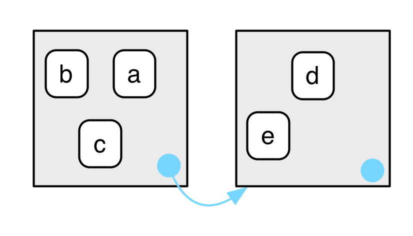

You can find the parent of an environment:

```r
parent.env(e2a)  # base
```

```
## <environment: R_GlobalEnv>
```

```r
env_parent(e2a)  # rlang
```

```
## <environment: R_GlobalEnv>
```

```r
parent.env(e2b)  # base
```

```
## <environment: 0x00000000165a3c78>
```

```r
env_parent(e2b)  # rlang
```

```
## <environment: 0x00000000165a3c78>
```

Only one environment doesn’t have a parent: the **empty** environment.

```r
emptyenv()  #base
```

```
## <environment: R_EmptyEnv>
```

```r
empty_env()  # rlang
```

```
## <environment: R_EmptyEnv>
```

```r
e2c <- env(empty_env(), d = 4, e = 5)
e2d <- env(e2c, a = 1, b = 2, c = 3)
```

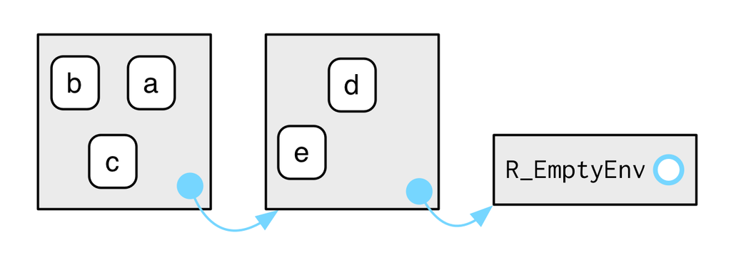

You’ll get an error if you try and find the parent of the empty environment:

```r
parent.env(emptyenv())  # base
```

```
## Error in parent.env(emptyenv()): the empty environment has no parent
```

```r
env_parent(empty_env())  # rlang
```

```
## Error: The empty environment has no parent
```

You can list all ancestors of an environment with `env_parents()`:

```r
env_parents(e2b)  # rlang, no base equivalent
```

```
## [[1]]   <env: 00000000165A3C78>
## [[2]] $ <env: global>
```

```r
env_parents(e2d)
```

```
## [[1]]   <env: 0000000018D008B8>
## [[2]] $ <env: empty>
```

By default, `env_parents()` continues until it hits either the global environment or the empty environment. You can control this behaviour with the `last` environment.

## 1.4 Getting and setting

You can get and set elements of an environment with `$` and `[[` in the same way as a list:

```r
e3 <- env(x = 1, y = 2)
e3$x
```

```
## [1] 1
```

```r
e3$z <- 3
e3[["z"]]
```

```
## [1] 3
```

But you can’t use `[[` with numeric indices, and you can’t use `[`:

```r
e3[[1]]
```

```
## Error in e3[[1]]: wrong arguments for subsetting an environment
```

```r
e3[c("x", "y")]
```

```
## Error in e3[c("x", "y")]: object of type 'environment' is not subsettable
```

`$` and `[[` will return `NULL` if the binding does not exist. Use `get()` or `env_get()` if you want an error or get a default value:

```r
e3$xyz
```

```r
get("xyz", pos = e3)  # base
```

```
## Error in get("xyz", pos = e3): object 'xyz' not found
```

```r
env_get(e3, "xyz")  # rlang
```

```
## Error in env_get(e3, "xyz"): object 'xyz' not found
```

```r
env_get(e3, "xyz", default = NA)
```

```
## [1] NA
```

You can add bindings to an environment:

```r
# base
assign("a", 10, e3)
assign("b", 20, e3)
ls.str(e3)
```

```
## a :  num 10
## b :  num 20
## x :  num 1
## y :  num 2
## z :  num 3
```

```r
# rlang
env_bind(e3, a = 10, b = 20)
```

You can determine if an environment has a binding:

```r
exists("x", e3)  # base
```

```
## [1] TRUE
```

```r
env_has(e3, "x")  # rlang
```

```
##    x
## TRUE
```

Unlike lists, setting an element to `NULL` does not remove it. In environments, that will create a new binding to `NULL`. Instead:

```r
# base
e4 <- new.env()
e4$a <- 1
e4$a <- NULL
ls(e4)
```

```
## [1] "a"
```

```r
rm("a", envir = e4)
ls(e4)
```

```
## character(0)
```

```r
# rlang
e4$a <- 1
ls(e4)
```

```
## [1] "a"
```

```r
env_unbind(e4, "a")
ls(e4)
```

```
## character(0)
```

Unbinding a name doesn’t delete the object. That’s the job of the garbage collector, which automatically removes objects with no names binding to them.

Beware `get()`, `assign()`, and `exists()`. The `inherits` argument defaults to `TRUE` meaning that they will inspect the supplied environment and all its ancestors.

## 1.5 Advanced bindings

`delayedAssign()` creates delayed bindings, which are evaluated the first time they are accessed. Behind the scenes, delayed bindings create promises, so behave in the same way as function arguments.

```r
p1 <- {
    print("hi1")
    1
}
```

```
## [1] "hi1"
```

```r
delayedAssign("p2", {
    print("hi2")
    2
})
p2
```

```
## [1] "hi2"
```

```
## [1] 2
```

**Delayed bindings** are used to implement `autoload()`, which makes R behave as if the package data is in memory, even though it’s only loaded from disk when you ask for it.

The idea of an **active binding** is that you can define something that looks like a variable but it actually invokes a function each time it is accessed. `makeActiveBinding()` creates active bindings which are re-computed every time they’re accessed:

```r
x <- runif(1)
x
```

```
## [1] 0.9272573
```

```r
x
```

```
## [1] 0.9272573
```

```r
rm(x)

# makeActiveBinding('x', function() runif(1), globalenv()) x x rm(x)
```

Active bindings can also be “set”:

```r
f <- function(x) {
    if (missing(x)) {
        print("get")
    } else {
        print(paste("set", x))
    }
}

makeActiveBinding("y", f, globalenv())
y  # 'get' value
```

```
## [1] "get"
```

```r
y <- 1  # 'set' value
```

```
## [1] "set 1"
```

```r
rm(y)
```

## 1.6 Exercises

1. List three ways in which an environment differs from a list.  
   **A**: The most important differences are:
- environments have reference semantics (they are modifed in place and can contain themselves)
- environments have parents
- environments are not ordered
- elements of environments need to be (uniquely) named
2. Create an environment as illustrated by this picture.

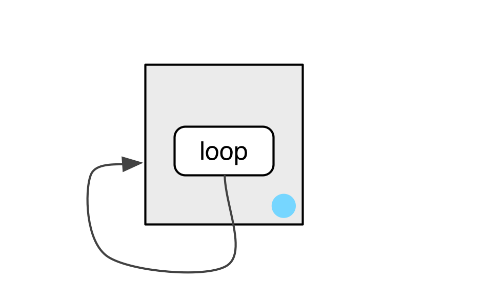

   **A**:

   ```r
   e <- new.env()
   e$loop <- e
   ```

3. Create an environment as illustrated by this picture.

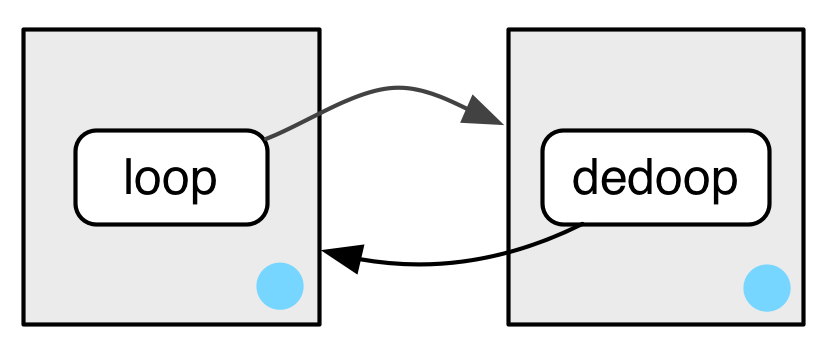

   **A**:

   ```r
   e1 <- new.env()
   e2 <- new.env()
   e1$loop <- e2
   e2$dedoop <- e1
   ```

4. Explain why `e[[1]]` and `e[c("a", "b")]` don’t make sense when e is an environment.  
   **A**: Environments are not ordered; environments are not subsettable for multiple elements

## 1.7 Recursing over environments

If you want to operate on every ancestor of an environment, it’s often convenient to write a recursive function. This section shows you how, applying your new knowledge of environments to write a function that given a name, finds the environment `where()` that name is defined, using R’s regular scoping rules.

The definition of `where()` is straightforward. It has two arguments: the name to look for (as a string), and the environment in which to start the search. (We’ll learn why `caller_env()` is a good default in calling environments.)

```r
where <- function(name, env = caller_env()) {
    if (identical(env, empty_env())) {
        # Base case
        stop("Can't find ", name, call. = FALSE)
    } else if (env_has(env, name)) {
        # Success case
        env
    } else {
        # Recursive case
        where(name, env_parent(env))
    }
}

where("yyy")
```

```
## Error: Can't find yyy
```

```r
x <- 5
where("x")
```

```
## <environment: R_GlobalEnv>
```

```r
where("mean")
```

```
## <environment: base>
```

It might help to see a picture. Imagine you have two environments, as in the following code and diagram:

```r
e4a <- env(empty_env(), a = 1, b = 2)
e4b <- env(e4a, x = 10, a = 11)
```

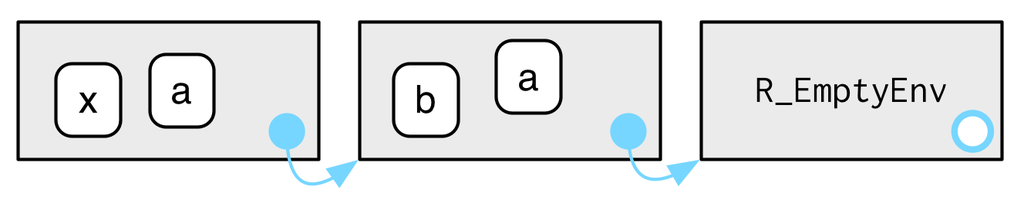

```r
where("a", e4a)
```

```
## <environment: 0x000000001641c928>
```

```r
where("b", e4a)
```

```
## <environment: 0x000000001641c928>
```

```r
where("c", e4a)
```

```
## Error: Can't find c
```

### 1.7.1 Exercises

1. Modify `where()` to return all environments that contain a binding for name. Carefully think through what type of object the function will need to return.

```r
where_all <- function(name, env = caller_env()) {
    if (identical(env, empty_env())) {
        # do nothing
    } else if (env_has(env, name)) {
        # Success case
        c(env, where_all(name, env_parent(env)))
    } else {
        # Recursive case
        where_all(name, env_parent(env))
    }
}

e1 <- env(empty_env(), x = 1)
attr(e1, "name") <- "e1"

e2 <- env(e1, x = 2)
attr(e2, "name") <- "e2"

x <- 3

where_all("x", e1)
```

```
## [[1]]
## <environment: 0x0000000018fcf968>
## attr(,"name")
## [1] "e1"
```

```r
where_all("x", e2)
```

```
## [[1]]
## <environment: 0x00000000190a3068>
## attr(,"name")
## [1] "e2"
##
## [[2]]
## <environment: 0x0000000018fcf968>
## attr(,"name")
## [1] "e1"
```

```r
where_all("x")
```

```
## [[1]]
## <environment: R_GlobalEnv>
```

```r
where_all("y", e1)
```

```r
# NOTE:
c("a", c("b", c("C")))
```

```
## [1] "a" "b" "C"
```

2. Write a function called `fget()` that finds only function objects. It should have two arguments, name and env, and should obey the regular scoping rules for functions: if there’s an object with a matching name that’s not a function, look in the parent. For an added challenge, also add an inherits argument which controls whether the function recurses up the parents or only looks in one environment.

```r
fget <- function(name, env = caller_env(), inherits = TRUE) {
    if (identical(env, empty_env())) {
        # do nothing
    } else if (env_has(env, name) && is.function(env[[name]])) {
        # Success case
        c(env[[name]], fget(name, env_parent(env)))
    } else {
        # Recursive case
        if (inherits)
            fget(name, env_parent(env)) else NULL
    }
}

e1 <- env(empty_env(), x = mean)
attr(e1, "name") <- "e1"

e2 <- env(e1, x = 2)
attr(e2, "name") <- "e2"

x <- 3

fget("x", e1)
```

```
## [[1]]
## function (x, ...)
## UseMethod("mean")
## <bytecode: 0x000000001849bf30>
## <environment: namespace:base>
```

```r
fget("x", e2)
```

```
## [[1]]
## function (x, ...)
## UseMethod("mean")
## <bytecode: 0x000000001849bf30>
## <environment: namespace:base>
```

```r
fget("x", e2, inherits = FALSE)
```

```r
fget("x")
```

```r
fget("y", e1)
```

## 1.8 Special environments

Most environments are not created by you (e.g. with `env()`) but are instead created by R. In this section, you’ll learn about the most important environments, starting with the package environments. You’ll then learn about the function environment bound to the function when it is created, and the (usually) ephemeral execution environment created every time the function is called. Finally, you’ll see how the package and function environments interact to support namespaces, which ensure that a package always behaves the same way, regardless of what other packages the user has loaded.

### 1.8.1 Package environments and the search path

Each package attached by `library()` or `require()` becomes one of the parents of the global environment. The immediate parent of the global environment is the last package you attached:

```r
parent.env(globalenv())  # base
```

```
## <environment: package:rlang>
## attr(,"name")
## [1] "package:rlang"
## attr(,"path")
## [1] "C:/Users/Tom/Documents/R/win-library/3.5/rlang"
```

```r
env_parent(global_env())  # rlang
```

```
## <environment: package:rlang>
## attr(,"name")
## [1] "package:rlang"
## attr(,"path")
## [1] "C:/Users/Tom/Documents/R/win-library/3.5/rlang"
```

If you follow all the parents back, you see the order in which every package has been attached. This is known as the **search path** because all objects in these environments can be found from the top-level interactive workspace.

```r
search()
```

```
##  [1] ".GlobalEnv"         "package:rlang"      "package:forcats"
##  [4] "package:stringr"    "package:purrr"      "package:readr"
##  [7] "package:tidyr"      "package:tibble"     "package:ggplot2"
## [10] "package:tidyverse"  "package:dplyr"      "package:magrittr"
## [13] "package:kableExtra" "package:knitr"      "package:pryr"
## [16] "package:lobstr"     "package:stats"      "package:graphics"
## [19] "package:grDevices"  "package:utils"      "package:datasets"
## [22] "package:methods"    "Autoloads"          "package:base"
```

The last two environments on the search path are always the same:

- The `Autoloads` environment uses delayed bindings to save memory by only loading package objects (like big datasets) when needed.
- The base environment, `package:base` or sometimes just `base`, is the environment of the base package. It is special because it has to be able to bootstrap the loading of all other packages. You can access it directly with `baseenv()` or `base_env()`.

Graphically, the search path looks like this:

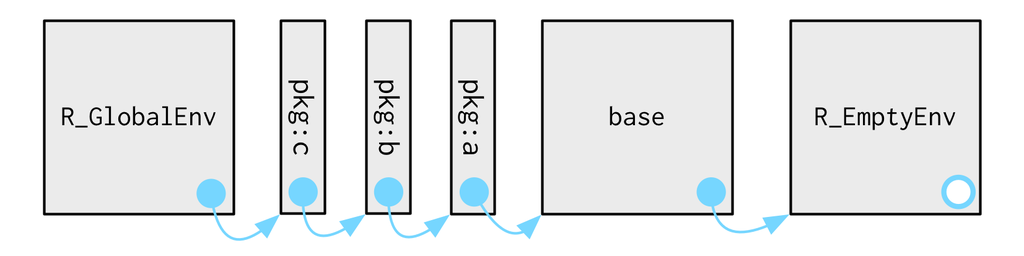

When you attach another package with `library()`, the parent environment of the global environment changes:

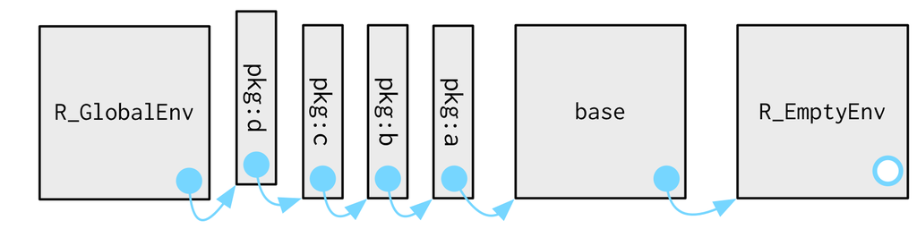